# Customer Behavior Analysis

# Collaborators

1. Aishwarya Puranik, aipu8487@colorado.edu
2. Purva Sushil Firodia, pufi1846@colorado.edu
3. Renita Blessina Sathiaraj, resa2241@colorado.edu

# About the Dataset

Call Center Restaurant Orders Dataset

Number of Rows: 72,314 \ Number of Columns: 17

- Date - Date in which the customer placed the order
- Time customer placed order - Time when customer placed the order
- Time order placed at restaurant - Time when the restaurant received the order
- Time driver arrived at restaurant - Time when driver arrived at the restaurant to pick up the order
- Delivery time - Time when the food was delivered to the Customer
- Driver ID - ID of the Drivers
- Driver Name - Name of the Driver
- Restaurant ID -ID of the Restaurant
- Customer ID - ID of the Customer
- Delivery Area - Cities in California namely Fremont, Hayward and Union city where the food needs to be delivered
- ASAP - categorical data for delivery as soon as possible
- Sub Total - Actual cost of the Food
- Delivery Fee - Delivery charges to be paided by the customer
- Service Fee - Service charges
- Discount - Discount amount if applicable
- Tip - optional amount tipped by the customer
- Refunded amount - Amount refunded to customer if the order is cancelled or if there is any discrepency in the payment

### Source link:

[Dataset source link](https://fp20analytics.com/datasets)

This dataset contains details of the order placed by the customers. In the below cell we can find the sample of the dataset with all the columns(details of the order).

# Method:

## Data Preprocessing:

```python
import pandas as pd
df = pd.read_excel('call-center_restaurant-orders-mv0x6oRrEEfBDJzn.xlsx')
df.tail(15)
```

|  | Date | Time customer placed order | Time order placed at restaurant | Time driver arrived at restaurant | Delivery time | Driver ID | Driver Name | Restaurant ID | Customer ID | Delivery Area | ASAP | Sub Total | Delivery fee | Service fee | Discount | Tip | Refunded amount |
| --- | --- | --- | --- | --- | --- | --- | --- | --- | --- | --- | --- | --- | --- | --- | --- | --- | --- |
| 72299 | 2020-04-30 | 00:54:40 | 00:55:16 | 01:58:44 | 02:23:25 | 9116 | Daniel | 7311 | 1116661 | Fremont | No | $49.95 | $11.83 | $3.70 | $2.00 | $6.55 | $0.00 |
| 72300 | 2020-04-30 | 03:26:08 | 03:28:47 | 03:46:04 | 04:42:04 | 9094 | Christopher | 7262 | 1012329 | Fremont | Yes | $65.57 | $3.86 | $3.16 | $2.00 | $6.26 | $0.00 |
| 72301 | 2020-04-30 | 01:55:56 | 02:06:29 | 02:17:00 | 03:08:47 | 9378 | Suzanne | 7308 | 1051457 | Union City | Yes | $189.83 | $3.22 | $5.31 | $2.00 | $21.17 | $0.00 |
| 72302 | 2020-04-30 | 03:35:17 | 03:41:04 | 04:28:01 | 05:15:19 | 9114 | Alicia | 7074 | 1011486 | Union City | Yes | $130.13 | $2.63 | $2.30 | $2.00 | $8.48 | $0.00 |
| 72303 | 2020-04-30 | 03:55:11 | 03:57:17 | NaN | 04:56:21 | 9149 | Wayne | 7285 | 1006497 | Hayward | Yes | $99.55 | $3.47 | $3.28 | $2.00 | $5.15 | $0.00 |
| 72304 | 2020-04-30 | 05:38:54 | 05:43:53 | 06:01:48 | 08:00:49 | 9223 | Carol | 7378 | 1007645 | Hayward | Yes | $122.69 | $9.92 | $4.34 | $2.00 | $13.10 | $0.00 |
| 72305 | 2020-04-30 | 05:17:55 | 05:30:19 | 05:37:54 | 06:08:54 | 9107 | Jill | 7324 | 1137549 | Hayward | Yes | $115.28 | $10.85 | $5.19 | $2.00 | $12.22 | $0.00 |
| 72306 | 2020-04-30 | 05:18:36 | 05:23:06 | 05:37:40 | 06:32:56 | 9245 | Frank | 7069 | 1029903 | Hayward | Yes | $61.92 | $10.02 | $3.75 | $15.00 | $4.04 | $0.00 |
| 72307 | 2020-04-30 | 05:34:46 | 05:44:22 | 06:02:00 | 06:49:04 | 9222 | Shirley | 7224 | 1058687 | Fremont | No | $80.20 | $0.94 | $6.50 | $2.00 | $5.23 | $0.00 |
| 72308 | 2020-04-30 | 06:55:28 | 07:41:24 | NaN | 09:15:27 | 9175 | Elizabeth | 7369 | 1172371 | Hayward | Yes | $91.15 | $3.41 | $1.95 | $2.00 | $5.94 | $0.00 |
| 72309 | 2020-04-30 | 07:38:34 | 07:41:28 | NaN | 08:30:50 | 9172 | Jocelyn | 7051 | 1185143 | Union City | No | $77.87 | $10.25 | $2.31 | $2.00 | $11.58 | $0.00 |
| 72310 | 2020-04-30 | 07:43:46 | 08:12:28 | 08:43:37 | 09:04:46 | 9324 | Tammy | 7041 | 1001989 | Hayward | Yes | $60.71 | $0.74 | $4.22 | $2.00 | $3.98 | $0.00 |
| 72311 | 2020-04-30 | 06:12:39 | 06:57:05 | 07:25:08 | 07:55:46 | 9045 | Mandy | 7292 | 1122688 | Union City | Yes | $120.38 | $7.96 | $2.55 | $2.00 | $6.40 | $0.00 |
| 72312 | 2020-04-30 | 07:30:35 | 07:45:41 | 09:06:48 | 09:47:23 | 9430 | Colleen | 7278 | 1043599 | Hayward | No | $100.65 | $12.40 | $5.20 | $2.00 | $6.58 | $0.00 |
| 72313 | 2020-04-30 | 09:17:49 | 09:31:16 | 09:56:09 | 11:59:40 | 9353 | Deborah | 7072 | 1178270 | Hayward | Yes | $198.47 | $13.65 | $4.74 | $2.00 | $22.19 | $0.00 |

```python
df.columns = ['DATE', 'TIME_CUSTOMER_PLACED_ORDER', 'TIME_ORDER_PLACED_AT_RESTAURANT',
              'TIME_DRIVER_ARRIVED_AT_RESTAURANT', 'DELIVERY_TIME', 'DRIVER_ID',
              'DRIVER_NAME', 'RESTAURANT_ID', 'CUSTOMER_ID', 'DELIVERY_AREA', 'ASAP',
              'SUB_TOTAL', 'DELIVERY_FEE', 'SERVICE_FEE', 'DISCOUNT', 'TIP',
              'REFUNDED_AMOUNT']
df.head(50)
```

|  | DATE | TIME_CUSTOMER_PLACED_ORDER | TIME_ORDER_PLACED_AT_RESTAURANT | TIME_DRIVER_ARRIVED_AT_RESTAURANT | DELIVERY_TIME | DRIVER_ID | DRIVER_NAME | RESTAURANT_ID | CUSTOMER_ID | DELIVERY_AREA | ASAP | SUB_TOTAL | DELIVERY_FEE | SERVICE_FEE | DISCOUNT | TIP | REFUNDED_AMOUNT |
| --- | --- | --- | --- | --- | --- | --- | --- | --- | --- | --- | --- | --- | --- | --- | --- | --- | --- |
| 0 | 2020-01-01 | 02:52:12 | 03:00:25 | 03:08:09 | 03:35:20 | 9329 | Christy | 7263 | 1143515 | Fremont | Yes | $21.39 | $0.43 | $3.83 | $2.00 | $1.40 | $0.00 |
| 1 | 2020-01-01 | 15:58:57 | 17:56:45 | 18:24:39 | 18:57:01 | 9175 | Elizabeth | 7247 | 1136820 | Hayward | Yes | $99.74 | $6.05 | $2.30 | $2.00 | $11.03 | $0.00 |
| 2 | 2020-01-01 | 19:02:37 | 19:12:51 | 19:19:59 | 19:31:09 | 9051 | Janet | 7293 | 1081871 | Hayward | Yes | $21.97 | $2.74 | $2.39 | $8.00 | $4.31 | $0.00 |
| 3 | 2020-01-01 | 04:01:57 | 04:08:18 | 04:13:02 | 04:37:57 | 9389 | Jacquelyn | 7046 | 1128255 | Union City | Yes | $32.79 | $0.12 | $2.55 | $2.00 | $8.55 | $0.00 |
| 4 | 2020-01-01 | 23:46:38 | 23:49:32 | 23:54:29 | 00:37:15 | 9187 | Lauren | 7385 | 1051183 | Hayward | Yes | $67.56 | $3.77 | $3.35 | $2.00 | $8.82 | $0.00 |
| 5 | 2020-01-01 | 03:54:30 | 03:57:30 | 04:10:26 | 04:41:00 | 9203 | Chloe | 7064 | 1129838 | Hayward | Yes | $21.18 | $6.78 | $3.79 | $8.00 | $1.59 | $0.00 |
| 6 | 2020-01-01 | 04:14:15 | 04:14:41 | 04:25:32 | 04:53:25 | 9180 | Shannon | 7121 | 1169616 | Union City | Yes | $63.91 | $4.76 | $2.44 | $2.00 | $10.09 | $0.00 |
| 7 | 2020-01-01 | 04:20:10 | 04:20:25 | 04:26:51 | 05:04:19 | 9107 | Jill | 7118 | 1177600 | Fremont | Yes | $46.82 | $2.54 | $1.99 | $8.00 | $2.33 | $0.00 |
| 8 | 2020-01-01 | 22:45:41 | 23:22:33 | NaN | 23:49:14 | 9034 | Bethany | 7286 | 1052229 | Hayward | No | $46.96 | $5.39 | $1.84 | $2.00 | $3.42 | $0.00 |
| 9 | 2020-01-01 | 01:41:41 | 02:07:07 | 02:11:55 | 02:30:18 | 9398 | Theresa | 7034 | 1189667 | Fremont | Yes | $23.96 | $5.29 | $1.86 | $2.00 | $2.89 | $0.00 |
| 10 | 2020-01-01 | 20:13:31 | 20:15:39 | 20:33:15 | 21:01:46 | 9110 | Denise | 7342 | 1032661 | Hayward | Yes | $24.25 | $2.69 | $1.31 | $2.00 | $4.75 | $0.00 |
| 11 | 2020-01-01 | 04:58:55 | 04:59:31 | NaN | 05:24:01 | 9279 | Ebony | 7146 | 1179405 | Hayward | Yes | $53.30 | $4.73 | $1.98 | $2.00 | $8.17 | $0.00 |
| 12 | 2020-01-01 | 17:55:46 | 19:09:27 | 19:24:13 | 19:29:56 | 9043 | Wendy | 7242 | 1055719 | Fremont | No | $26.30 | $6.61 | $2.17 | $2.00 | $1.09 | $0.00 |
| 13 | 2020-01-01 | 16:49:32 | 17:50:50 | NaN | 18:25:00 | 9383 | Jennifer | 7275 | 1067334 | Union City | No | $76.10 | $3.51 | $2.12 | $2.00 | $4.96 | $0.00 |
| 14 | 2020-01-01 | 20:50:57 | 20:56:41 | 21:17:03 | 21:45:20 | 9189 | Diana | 7408 | 1153261 | Hayward | Yes | $56.08 | $0.85 | $2.43 | $14.00 | $7.32 | $0.00 |
| 15 | 2020-01-01 | 17:47:16 | 17:47:37 | 18:40:28 | 18:57:23 | 9267 | Amanda | 7109 | 1157169 | Fremont | No | $29.95 | $3.71 | $1.00 | $2.00 | $0.00 | $0.00 |
| 16 | 2020-01-01 | 02:14:46 | 02:32:55 | 02:44:18 | 03:15:50 | 9222 | Shirley | 7178 | 1033392 | Union City | Yes | $23.53 | $1.08 | $1.05 | $8.00 | $0.00 | $0.00 |
| 17 | 2020-01-01 | 02:23:37 | 02:29:44 | 02:38:02 | 02:59:30 | 9185 | Emily | 7407 | 1108599 | Hayward | Yes | $32.72 | $6.79 | $2.89 | $2.00 | $2.14 | $0.00 |
| 18 | 2020-01-01 | 19:21:54 | 19:25:02 | NaN | 20:32:06 | 9327 | Janice | 7262 | 1181283 | Fremont | Yes | $35.65 | $3.08 | $2.43 | $2.00 | $4.99 | $0.00 |
| 19 | 2020-01-01 | 01:03:47 | 01:19:43 | 01:52:29 | 02:02:51 | 9096 | Nancy | 7027 | 1037547 | Hayward | Yes | $30.65 | $3.09 | $2.66 | $2.00 | $4.00 | $0.00 |
| 20 | 2020-01-01 | 18:23:45 | 18:49:22 | 19:07:11 | 19:23:17 | 9216 | Michelle | 7267 | 1174703 | Hayward | No | $158.61 | $2.82 | $3.73 | $2.00 | $25.72 | $0.00 |
| 21 | 2020-01-01 | 02:32:46 | 02:36:38 | NaN | 03:30:03 | 9056 | Joyce | 7293 | 1125608 | Union City | Yes | $64.78 | $5.88 | $2.19 | $2.00 | $3.40 | $0.00 |
| 22 | 2020-01-01 | 04:09:48 | 04:10:21 | NaN | 04:40:34 | 9165 | Sara | 7054 | 1066989 | Fremont | Yes | $38.49 | $6.03 | $3.73 | $2.00 | $2.51 | $0.00 |
| 23 | 2020-01-01 | 01:04:11 | 01:07:44 | 01:20:48 | 01:47:53 | 9204 | Amy | 7331 | 1035620 | Hayward | Yes | $43.26 | $5.79 | $2.98 | $2.00 | $5.64 | $0.00 |
| 24 | 2020-01-01 | 19:10:07 | 19:30:21 | 19:42:45 | 20:10:59 | 9065 | Wanda | 7123 | 1143119 | Hayward | Yes | $60.35 | $5.19 | $1.19 | $8.00 | $7.88 | $0.00 |
| 25 | 2020-01-01 | 01:16:40 | 01:18:19 | 01:53:22 | 02:04:57 | 9346 | Cynthia | 7357 | 1061142 | Hayward | Yes | $81.65 | $5.47 | $2.77 | $8.00 | $15.99 | $0.00 |
| 26 | 2020-01-01 | 02:22:58 | 02:25:15 | 02:44:59 | 03:09:37 | 9168 | Norma | 7192 | 1190031 | Union City | Yes | $50.61 | $2.24 | $1.71 | $2.00 | $3.30 | $0.00 |
| 27 | 2020-01-01 | 00:20:32 | 00:20:51 | 00:27:58 | 01:06:09 | 9132 | Andrea | 7251 | 1113319 | Union City | Yes | $95.33 | $6.02 | $3.09 | $2.00 | $25.65 | $0.00 |
| 28 | 2020-01-01 | 02:55:18 | 02:57:01 | NaN | 03:45:50 | 9395 | Rebecca | 7352 | 1032050 | Union City | Yes | $68.26 | $2.06 | $2.08 | $2.00 | $7.25 | $0.00 |
| 29 | 2020-01-01 | 00:41:22 | 01:00:46 | 01:20:41 | 01:37:34 | 9259 | Kimberly | 7063 | 1107652 | Union City | Yes | $53.24 | $5.87 | $1.16 | $2.00 | $0.00 | $0.00 |
| 30 | 2020-01-01 | 02:11:53 | 02:30:30 | 02:39:46 | 03:24:01 | 9273 | Heather | 7106 | 1146933 | Fremont | Yes | $60.55 | $3.08 | $3.47 | $8.00 | $3.95 | $0.00 |
| 31 | 2020-01-01 | 23:22:01 | 23:32:38 | 23:57:50 | 00:21:25 | 9105 | Mildred | 7010 | 1117792 | Fremont | No | $111.07 | $0.54 | $3.94 | $2.00 | $18.57 | $0.00 |
| 32 | 2020-01-01 | 02:36:52 | 02:37:55 | 02:54:58 | 03:10:56 | 9104 | Lori | 7289 | 1044149 | Fremont | Yes | $46.90 | $2.36 | $3.58 | $2.00 | $3.06 | $0.00 |
| 33 | 2020-01-01 | 00:50:11 | 00:51:43 | NaN | 01:55:36 | 9151 | Catherine | 7119 | 1167092 | Union City | Yes | $208.76 | $3.94 | $1.35 | $2.00 | $13.63 | $0.00 |
| 34 | 2020-01-01 | 00:15:26 | 00:16:25 | NaN | 00:51:44 | 9010 | Marie | 7148 | 1189869 | Union City | Yes | $60.50 | $4.51 | $1.54 | $2.00 | $3.95 | $0.00 |
| 35 | 2020-01-01 | 22:42:04 | 23:31:14 | 23:56:14 | 00:43:26 | 9104 | Lori | 7109 | 1168303 | Fremont | No | $75.31 | $7.45 | $3.47 | $2.00 | $9.83 | $0.00 |
| 36 | 2020-01-01 | 20:11:34 | 20:11:54 | 20:29:16 | 20:36:43 | 9336 | Pamela | 7361 | 1069195 | Fremont | Yes | $22.03 | $2.81 | $3.86 | $2.00 | $0.84 | $0.00 |
| 37 | 2020-01-01 | 18:56:52 | 19:14:47 | 19:32:12 | 19:53:50 | 9067 | Brenda | 7300 | 1200360 | Hayward | Yes | $143.76 | $7.51 | $3.20 | $2.00 | $8.14 | $0.00 |
| 38 | 2020-01-01 | 01:02:43 | 01:06:37 | 01:24:34 | 01:42:00 | 9074 | Frances | 7271 | 1174478 | Union City | Yes | $39.17 | $2.18 | $2.47 | $2.00 | $2.57 | $0.00 |
| 39 | 2020-01-01 | 20:14:23 | 20:23:45 | NaN | 21:05:29 | 9353 | Deborah | 7151 | 1104799 | Hayward | Yes | $55.09 | $3.18 | $2.19 | $2.00 | $8.50 | $0.00 |
| 40 | 2020-01-01 | 02:32:55 | 02:36:27 | 02:42:30 | 03:02:42 | 9276 | Sandra | 7211 | 1136684 | Fremont | Yes | $26.38 | $4.19 | $1.96 | $2.00 | $1.73 | $0.00 |
| 41 | 2020-01-01 | 21:58:38 | 22:00:20 | 22:24:08 | 22:38:35 | 9437 | Bonnie | 7252 | 1160145 | Fremont | Yes | $57.44 | $0.82 | $3.94 | $2.00 | $3.74 | $0.00 |
| 42 | 2020-01-01 | 02:23:30 | 02:23:41 | 03:04:59 | 03:16:57 | 9307 | Jessica | 7023 | 1198781 | Fremont | Yes | $34.22 | $3.22 | $3.28 | $2.00 | $2.24 | $0.00 |
| 43 | 2020-01-01 | 20:26:16 | 20:28:33 | 20:44:06 | 21:10:55 | 9115 | Kathryn | 7230 | 1199880 | Fremont | Yes | $203.42 | $6.94 | $2.20 | $8.00 | $22.52 | $0.00 |
| 44 | 2020-01-01 | 02:59:05 | 02:59:27 | 03:07:22 | 03:28:00 | 9074 | Frances | 7188 | 1088717 | Hayward | Yes | $30.56 | $3.17 | $2.25 | $2.00 | $2.00 | $0.00 |
| 45 | 2020-01-01 | 19:18:47 | 19:25:48 | NaN | 20:06:40 | 9117 | Rose | 7135 | 1086611 | Fremont | Yes | $46.31 | $7.07 | $3.40 | $2.00 | $6.91 | $0.00 |
| 46 | 2020-01-01 | 00:40:07 | 00:41:52 | 00:54:13 | 01:04:28 | 9438 | Ruby | 7239 | 1165971 | Fremont | Yes | $19.19 | $7.23 | $2.91 | $2.00 | $0.67 | $0.00 |
| 47 | 2020-01-01 | 01:04:00 | 01:06:29 | NaN | 01:49:34 | 9330 | Dorothy | 7304 | 1062964 | Fremont | Yes | $80.45 | $1.50 | $3.50 | $2.00 | $10.50 | $0.00 |
| 48 | 2020-01-01 | 00:27:53 | 00:37:17 | NaN | 02:15:33 | 9409 | Kathleen | 7242 | 1148686 | Union City | Yes | $67.48 | $6.37 | $3.93 | $2.00 | $4.41 | $0.00 |
| 49 | 2020-01-01 | 01:07:54 | 01:10:23 | 01:23:02 | 01:40:07 | 9182 | Joan | 7224 | 1002131 | Hayward | Yes | $33.43 | $1.92 | $2.83 | $2.00 | $1.52 | $0.00 |

```python
df['REFUNDED_AMOUNT'] = df['REFUNDED_AMOUNT'].str.replace('$', '')
df['SUB_TOTAL'] = df['SUB_TOTAL'].replace('[\$,]', '', regex=True).astype(float)
df['DELIVERY_FEE'] = df['DELIVERY_FEE'].replace('[\$,]', '', regex=True).astype(float)
df['SERVICE_FEE'] = df['SERVICE_FEE'].replace('[\$,]', '', regex=True).astype(float)
df['DISCOUNT'] = df['DISCOUNT'].replace('[\$,]', '', regex=True).astype(float)
df['TIP'] = df['TIP'].replace('[\$,]', '', regex=True).astype(float)
```

```python
df.isna().sum()
```

```
DATE                                     0
TIME_CUSTOMER_PLACED_ORDER               0
TIME_ORDER_PLACED_AT_RESTAURANT        160
TIME_DRIVER_ARRIVED_AT_RESTAURANT    18124
DELIVERY_TIME                            0
DRIVER_ID                                0
DRIVER_NAME                              0
RESTAURANT_ID                            0
CUSTOMER_ID                              0
DELIVERY_AREA                            0
ASAP                                     0
SUB_TOTAL                                0
DELIVERY_FEE                             0
SERVICE_FEE                              0
DISCOUNT                                 0
TIP                                      0
REFUNDED_AMOUNT                          0
dtype: int64
```

```python
df=df.dropna()
```

```python
df.isna().sum()
```

```
DATE                                 0
TIME_CUSTOMER_PLACED_ORDER           0
TIME_ORDER_PLACED_AT_RESTAURANT      0
TIME_DRIVER_ARRIVED_AT_RESTAURANT    0
DELIVERY_TIME                        0
DRIVER_ID                            0
DRIVER_NAME                          0
RESTAURANT_ID                        0
CUSTOMER_ID                          0
DELIVERY_AREA                        0
ASAP                                 0
SUB_TOTAL                            0
DELIVERY_FEE                         0
SERVICE_FEE                          0
DISCOUNT                             0
TIP                                  0
REFUNDED_AMOUNT                      0
dtype: int64
```

```python
def time_difference(row):
    order_time = row['TIME_ORDER_PLACED_AT_RESTAURANT']
    total_time = row['DELIVERY_TIME']

    time_diff_seconds = (total_time.hour * 3600 + total_time.minute * 60 + total_time.second) - \
                        (order_time.hour * 3600 + order_time.minute * 60 + order_time.second)

    return time_diff_seconds
```

```python
def calculate_time_difference(row):
    order_time = row['TIME_ORDER_PLACED_AT_RESTAURANT']
    driver_time = row['TIME_DRIVER_ARRIVED_AT_RESTAURANT']

    time_diff_seconds = (driver_time.hour * 3600 + driver_time.minute * 60 + driver_time.second) - \
                        (order_time.hour * 3600 + order_time.minute * 60 + order_time.second)

    return time_diff_seconds
```

```python
df['TIME_ORDER_PLACED_AT_RESTAURANT'] = pd.to_datetime(df['TIME_ORDER_PLACED_AT_RESTAURANT'], format='%H:%M:%S').dt.time
df['TIME_DRIVER_ARRIVED_AT_RESTAURANT'] = pd.to_datetime(df['TIME_DRIVER_ARRIVED_AT_RESTAURANT'], format='%H:%M:%S').dt.time
df['DELIVERY_TIME'] = pd.to_datetime(df['DELIVERY_TIME'], format='%H:%M:%S').dt.time

df['TOTAL_TIME_TAKEN_SECONDS'] = df.apply(time_difference, axis=1)

df['TOTAL_TIME_TAKEN_MINUTES'] = df['TOTAL_TIME_TAKEN_SECONDS'] / 60

df[['TIME_ORDER_PLACED_AT_RESTAURANT', 'TIME_DRIVER_ARRIVED_AT_RESTAURANT', 'TOTAL_TIME_TAKEN_SECONDS','TOTAL_TIME_TAKEN_MINUTES']].head()
```

|  | TIME_ORDER_PLACED_AT_RESTAURANT | TIME_DRIVER_ARRIVED_AT_RESTAURANT | TOTAL_TIME_TAKEN_SECONDS | TOTAL_TIME_TAKEN_MINUTES |
| --- | --- | --- | --- | --- |
| 0 | 03:00:25 | 03:08:09 | 2095 | 34.916667 |
| 1 | 17:56:45 | 18:24:39 | 3616 | 60.266667 |
| 2 | 19:12:51 | 19:19:59 | 1098 | 18.300000 |
| 3 | 04:08:18 | 04:13:02 | 1779 | 29.650000 |
| 4 | 23:49:32 | 23:54:29 | -83537 | -1392.283333 |

```python
# Removing negative values
df = df[df['TOTAL_TIME_TAKEN_MINUTES'] >= 0]
```

```python
df.reset_index(drop=True, inplace=True)
```

### Customer behaviour analysis (EDA)

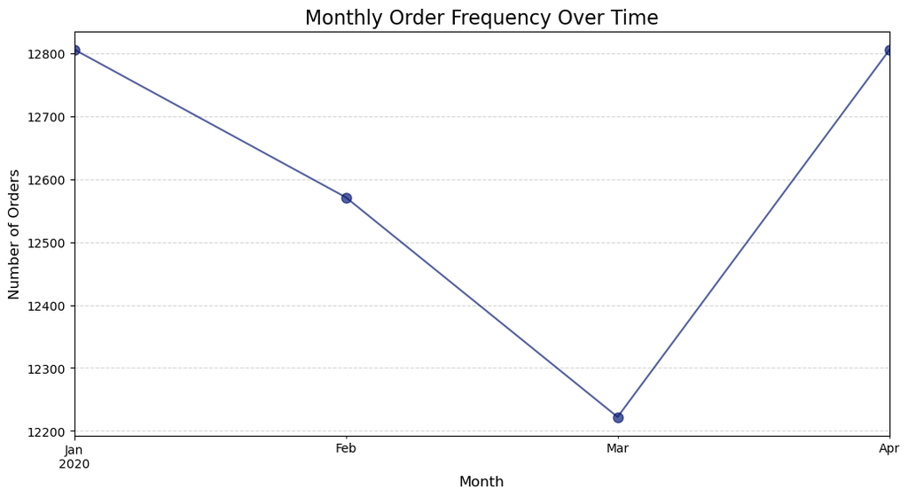

```python
import pandas as pd
import matplotlib.pyplot as plt
import seaborn as sns  # Optional for color palettes

# Assuming 'Date' is already a datetime column
df['DATE'] = pd.to_datetime(df['DATE'])

# Group by month and count the number of orders for each month
monthly_order_frequency = df.groupby(df['DATE'].dt.to_period("M")).size()

# Set a color palette for the plot (optional)
sns.set_palette("viridis")

# Plot the time series with enhancements
plt.figure(figsize=(12, 6))
monthly_order_frequency.plot(marker='o', linestyle='-', markersize=8, alpha=0.7, color = "#0b1d78")

# Add grid
plt.grid(True, linestyle='--', alpha=0.5)

# Set plot title and labels
plt.title('Monthly Order Frequency Over Time', fontsize=16)
plt.xlabel('Month', fontsize=12)
plt.ylabel('Number of Orders', fontsize=12)

# Add legend (if applicable)
# plt.legend(['Order Frequency'], loc='upper left')

plt.show()
```

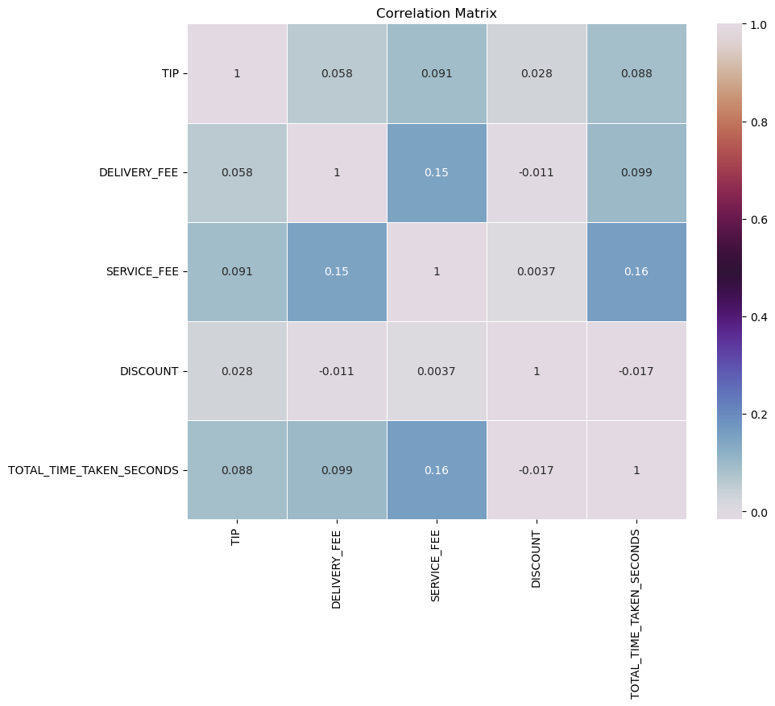

```python
import pandas as pd
import seaborn as sns
import matplotlib.pyplot as plt

# Assuming 'Delivery time', 'Tip', and other relevant columns exist in your dataset
monetary_columns = ['DELIVERY_TIME', 'TIP', 'DELIVERY_FEE', 'SERVICE_FEE', 'DISCOUNT', 'REFUNDED_AMOUNT','TOTAL_TIME_TAKEN_SECONDS']

# Calculate the correlation matrix
correlation_matrix = df[monetary_columns].corr()
# Plot the correlation matrix using a heatmap
plt.figure(figsize=(10, 8))
sns.heatmap(correlation_matrix, annot=True, cmap='twilight', linewidths=.5)
plt.title('Correlation Matrix')
plt.show()
```

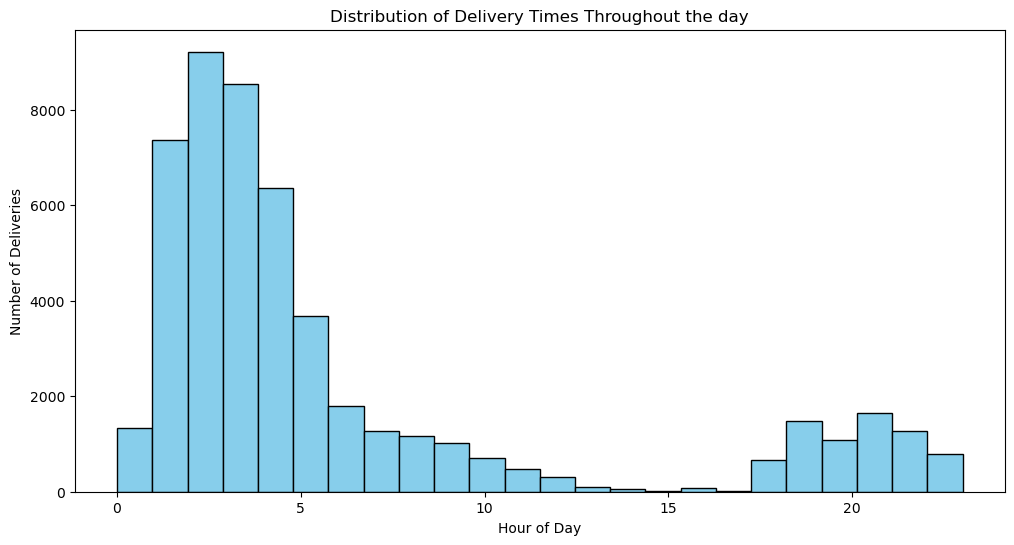

```python
df['DELIVERY_TIME'] = pd.to_datetime(df['DELIVERY_TIME'], format='%H:%M:%S').dt.time

df['DELIVERY_HOUR'] = pd.to_datetime(df['DELIVERY_TIME'], format='%H:%M:%S').dt.hour

plt.figure(figsize=(12, 6))
plt.hist(df['DELIVERY_HOUR'], bins=24, edgecolor='black', color = "#87CEEB")
plt.title('Distribution of Delivery Times Throughout the day')
plt.xlabel('Hour of Day')
plt.ylabel('Number of Deliveries')
plt.show()

average_delivery_time = df['DELIVERY_HOUR'].mean()
```

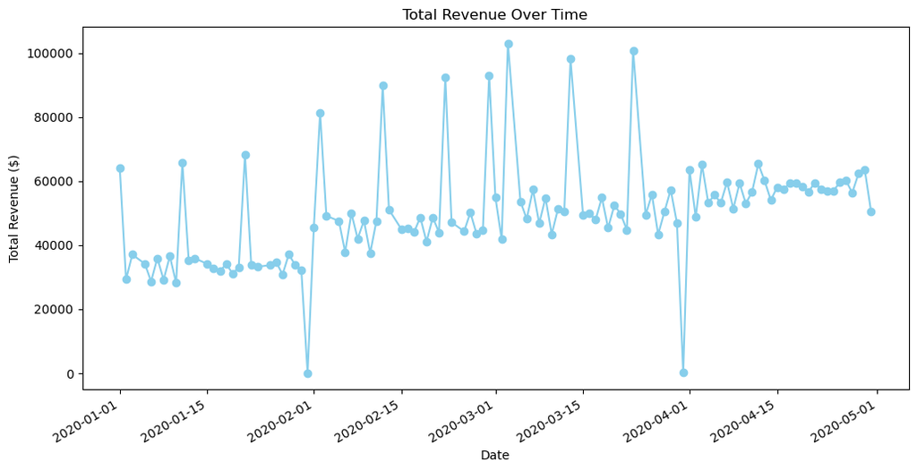

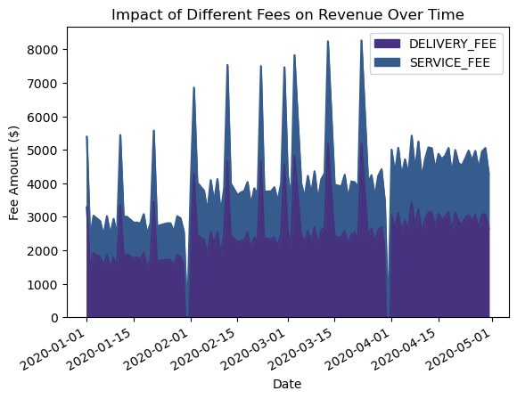

```python
currency_columns = ['SUB_TOTAL', 'DELIVERY_FEE', 'SERVICE_FEE', 'TIP', 'REFUNDED_AMOUNT']
df['SUB_TOTAL'] = pd.to_numeric(df['SUB_TOTAL'], errors='coerce')
df['DELIVERY_FEE'] = pd.to_numeric(df['DELIVERY_FEE'], errors='coerce')
df['SERVICE_FEE'] = pd.to_numeric(df['SERVICE_FEE'], errors='coerce')
df['TIP'] = pd.to_numeric(df['TIP'], errors='coerce')
df['REFUNDED_AMOUNT'] = pd.to_numeric(df['REFUNDED_AMOUNT'], errors='coerce')
# Calculate total revenue for each order
df['TOTAL_REVENUE'] = df['SUB_TOTAL'] + df['DELIVERY_FEE'] + df['SERVICE_FEE'] + df['TIP'] - df['REFUNDED_AMOUNT']

# Analyzing total revenue during specific time periods
revenue_by_date = df.groupby('DATE')['TOTAL_REVENUE'].sum()

plt.figure(figsize=(12, 6))
revenue_by_date.plot(kind='line', marker='o', color = "#87CEEB")
plt.title('Total Revenue Over Time')
plt.xlabel('Date')
plt.ylabel('Total Revenue ($)')
plt.show()

fee_columns = ['DELIVERY_FEE', 'SERVICE_FEE']

revenue_by_fee = df.groupby('DATE')[fee_columns].sum()

plt.figure(figsize=(12, 6))
revenue_by_fee.plot(kind='area', stacked=True)
plt.title('Impact of Different Fees on Revenue Over Time')
plt.xlabel('Date')
plt.ylabel('Fee Amount ($)')
plt.show()
```

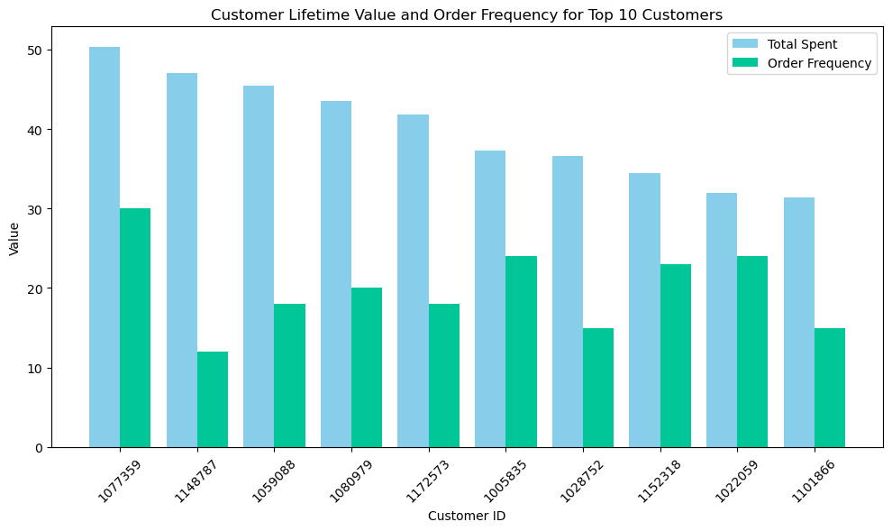

```python
# Calculating total spent per customer
total_spent = df.groupby('CUSTOMER_ID')['SUB_TOTAL'].sum()

# Calculating frequency of orders per customer
order_frequency = df['CUSTOMER_ID'].value_counts()

# Calculating CLV based on total spent and order frequency
clv_data = pd.DataFrame({
    'TOTAL_SPENT': total_spent,
    'ORDER_FREQUENCY': order_frequency
})

clv_data['TOTAL_SPENT'] = pd.to_numeric(clv_data['TOTAL_SPENT'], errors='coerce')

# Dropping rows with NaN values in 'TOTAL_SPENT' column
clv_data.dropna(subset=['TOTAL_SPENT'], inplace=True)

top_customers = clv_data.nlargest(10, 'TOTAL_SPENT')
#print(top_customers)

# Plotting Customer Lifetime Value (CLV) and Order Frequency for top customers
fig, ax = plt.subplots(figsize=(10, 6))

# Creating indices for x-axis positions
indices = range(len(top_customers))
bar_width = 0.4
ax.bar(indices, top_customers['TOTAL_SPENT']/100, bar_width, label='Total Spent', color='#87CEEB')
ax.bar([i + bar_width for i in indices], top_customers['ORDER_FREQUENCY'], bar_width, label='Order Frequency', color='#00c698')

ax.set_xticks([i + bar_width / 2 for i in indices])
ax.set_xticklabels(top_customers.index)
plt.xlabel('Customer ID')

ax.set_ylabel('Value')
plt.title('Customer Lifetime Value and Order Frequency for Top 10 Customers')
plt.legend()

plt.xticks(rotation=45)

plt.tight_layout()
plt.show()
```

## Customer segmentations:

### 1. Segments of Engagements levels

```python
df['OrderFrequency'] = pd.cut(df.groupby('CUSTOMER_ID')['DATE'].transform('count'),
                                bins=[0, 1, 4, float('inf')],
                                labels=['Inactive', 'Occasional', 'Active'])

df['TotalSpending'] = pd.qcut(df.groupby('CUSTOMER_ID')['SUB_TOTAL'].transform('sum'),
                                q=[0, 0.25, 0.75, 1],
                                labels=['Low Spender', 'Medium Spender', 'High Spender'])

# Convert Categorical columns to strings before concatenation
df['OrderFrequency'] = df['OrderFrequency'].astype(str)
df['TotalSpending'] = df['TotalSpending'].astype(str)

# Combine criteria to get overall engagement level
df['EngagementLevel'] = df['OrderFrequency'] + " " + df['TotalSpending']

# Display the result
df[['CUSTOMER_ID','EngagementLevel']]
```

[output not shown]

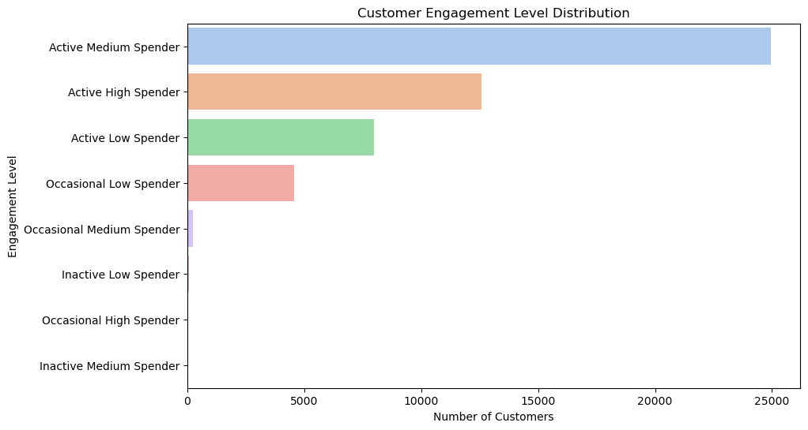

```python
#Visualizing the segments
import seaborn as sns
import matplotlib.pyplot as plt
ax.set_facecolor('#f0f0f0')
plt.figure(figsize=(10, 6))
ax = sns.countplot(y='EngagementLevel', data=df, order=df['EngagementLevel'].value_counts().index, palette='pastel')

plt.title('Customer Engagement Level Distribution')
plt.xlabel('Number of Customers')
plt.ylabel('Engagement Level')
plt.show()
```

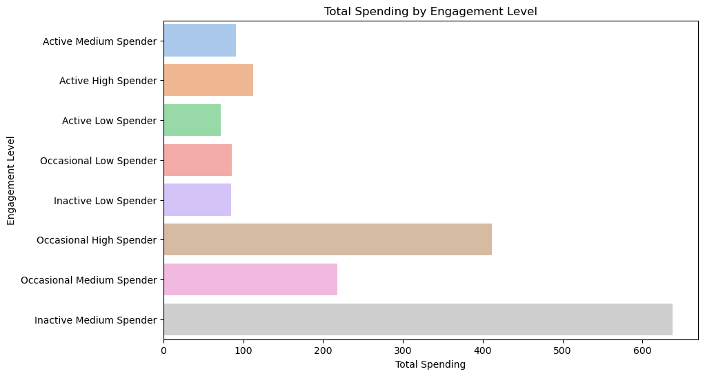

```python
# Horizontal bar plot of Total Spending by Engagement Level
plt.figure(figsize=(10, 6))
sns.barplot(x='SUB_TOTAL', y='EngagementLevel', data=df, ci=None, palette='pastel')
plt.title('Total Spending by Engagement Level')
plt.xlabel('Total Spending')
plt.ylabel('Engagement Level')
plt.show()
```

### 2. Customer segments based on their ordering habits

```python
import pandas as pd
from sklearn.cluster import KMeans
from sklearn.preprocessing import LabelEncoder, StandardScaler


label_encoder = LabelEncoder()
df['DeliveryTimeEncoded'] = label_encoder.fit_transform(df['DELIVERY_TIME'])

features = df[['DeliveryTimeEncoded']]

scaler = StandardScaler()
features_scaled = scaler.fit_transform(features)

optimal_k = 2 #Elbow method below suggests 2 is optimum number of clusters

kmeans = KMeans(n_clusters=optimal_k, random_state=42)
df['DeliveryTimeSegment'] = kmeans.fit_predict(features_scaled)

segment_mapping = {
    0: 'ASAP Delivery',
    1: 'Scheduled Delivery'
}

df['DeliveryTimeSegment'] = df['DeliveryTimeSegment'].map(segment_mapping)

print(df[['CUSTOMER_ID', 'DELIVERY_TIME', 'DeliveryTimeSegment']])
```

```
       CUSTOMER_ID DELIVERY_TIME DeliveryTimeSegment
0          1143515      03:35:20       ASAP Delivery
1          1136820      18:57:01  Scheduled Delivery
2          1081871      19:31:09  Scheduled Delivery
3          1128255      04:37:57       ASAP Delivery
4          1129838      04:41:00       ASAP Delivery
...            ...           ...                 ...
50399      1058687      06:49:04  Scheduled Delivery
50400      1001989      09:04:46  Scheduled Delivery
50401      1122688      07:55:46  Scheduled Delivery
50402      1043599      09:47:23  Scheduled Delivery
50403      1178270      11:59:40  Scheduled Delivery

[50404 rows x 3 columns]
```

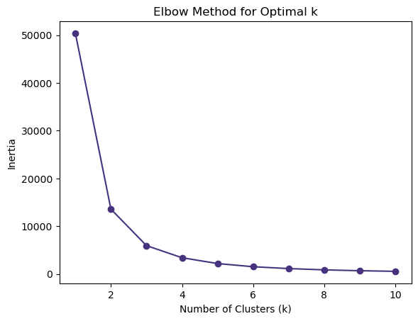

```python
# PErforming Elbow method to find out optimum number of clusters
import matplotlib.pyplot as plt
from sklearn.cluster import KMeans
from sklearn.preprocessing import StandardScaler
from sklearn.decomposition import PCA
from sklearn.preprocessing import LabelEncoder


k_values = range(1, 11)

inertia_values = []
for k in k_values:
    kmeans = KMeans(n_clusters=k, random_state=42)
    kmeans.fit(features_scaled)
    inertia_values.append(kmeans.inertia_)

# Plot the elbow curve
plt.plot(k_values, inertia_values, marker='o')
plt.xlabel('Number of Clusters (k)')
plt.ylabel('Inertia')
plt.title('Elbow Method for Optimal k')
plt.show()
```

- As per the above plot, we can say the two is the optimal number of clusters.

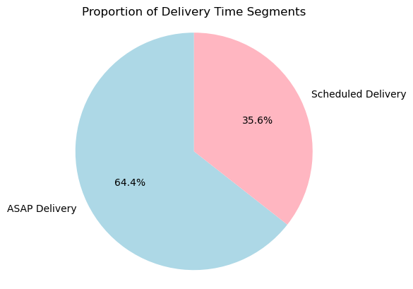

```python
# Visualizing the segments
segment_counts = df['DeliveryTimeSegment'].value_counts()
plt.pie(segment_counts, labels=segment_counts.index, autopct='%1.1f%%', startangle=90, colors=['#add8e6', '#ffb6c1'])
plt.axis('equal')  # Equal aspect ratio ensures that the pie is drawn as a circle.
plt.title('Proportion of Delivery Time Segments')
plt.show()
```

#### Suggested Strategies:

- ASAP Delivery Segment:

Offer discounts or promotions to clients who request expedited delivery in order to encourage prompt delivery. Stress how quick and easy it is to get options for instant delivery. Real-Time Updates: Give customers real-time information on the state of their orders, including tracking their delivery and order preparation. bargains for Instant Gratification: To encourage more frequent and quick purchases, create unique discounts or bargains that are only accessible for ASAP deliveries.

- Scheduled Delivery Segment:

Flexible Scheduling Options: Give clients a range of delivery window times to meet their desired timetables. Permit them to select precise delivery windows. Provide membership or subscription services with regular delivery schedules. Customers that value routine and preparation may find this to be especially appealing. Prompt Alerts: Notify clients well in advance about the deliveries that are scheduled. Personalized recommendations based on their previous orders should be included.

### 3.Segments by Time-of-Day :

```python
import pandas as pd
from sklearn.cluster import KMeans
from sklearn.preprocessing import LabelEncoder
import matplotlib.pyplot as plt

df["Date"]=pd.to_datetime(df['DATE'])


df['OrderDateTime'] = df['DATE'] + pd.to_timedelta(df['TIME_CUSTOMER_PLACED_ORDER'].astype(str))

df['OrderHour'] = df['OrderDateTime'].dt.hour

label_encoder = LabelEncoder()
df['OrderHourEncoded'] = label_encoder.fit_transform(df['OrderHour'])

features = df[['OrderHourEncoded']]

# Choosing the optimal number of clusters (e.g., 4 for breakfast, lunch, dinner, late-night)
optimal_k = 4

kmeans = KMeans(n_clusters=optimal_k, random_state=42)
df['TimeOfDaySegment'] = kmeans.fit_predict(features)

time_of_day_mapping = {
    0: 'Breakfast',
    1: 'Lunch',
    2: 'Dinner',
    3: 'Late-Night'
}

df['TimeOfDaySegment'] = df['TimeOfDaySegment'].map(time_of_day_mapping)

print(df[['DATE', 'TIME_CUSTOMER_PLACED_ORDER', 'OrderHour', 'TimeOfDaySegment']])
```

```
            DATE TIME_CUSTOMER_PLACED_ORDER  OrderHour TimeOfDaySegment
0     2020-01-01                   02:52:12          2           Dinner
1     2020-01-01                   15:58:57         15            Lunch
2     2020-01-01                   19:02:37         19            Lunch
3     2020-01-01                   04:01:57          4        Breakfast
4     2020-01-01                   03:54:30          3        Breakfast
...          ...                        ...        ...              ...
50399 2020-04-30                   05:34:46          5        Breakfast
50400 2020-04-30                   07:43:46          7       Late-Night
50401 2020-04-30                   06:12:39          6        Breakfast
50402 2020-04-30                   07:30:35          7       Late-Night
50403 2020-04-30                   09:17:49          9       Late-Night

[50404 rows x 4 columns]
```

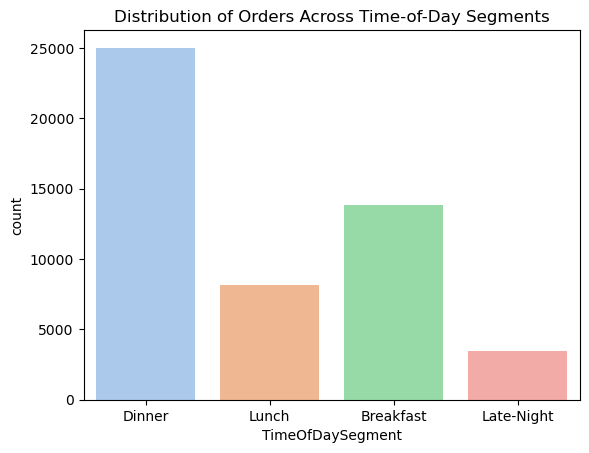

```python
# Visualizing the segments
sns.countplot(x='TimeOfDaySegment', data=df, palette='pastel')
plt.title('Distribution of Orders Across Time-of-Day Segments')
plt.show()
```

### Suggested Strategies:

Breakfast (Cluster 0): Offer morning promotions. Highlight quick delivery options.

### Churn Prediction

#### Usuing Random Forest

```python
import pandas as pd
from sklearn.model_selection import train_test_split
from sklearn.ensemble import RandomForestClassifier
from sklearn.datasets import make_classification
from sklearn.impute import SimpleImputer
from sklearn.metrics import accuracy_score, classification_report, confusion_matrix
from sklearn.model_selection import RepeatedStratifiedKFold
from imblearn.under_sampling import RandomUnderSampler
from imblearn.over_sampling import RandomOverSampler

df['Recency'] = (pd.to_datetime('2020-04-30') - pd.to_datetime(df['DATE'], format='%m/%d/%Y')).dt.days
df['OrderFrequency'] = df.groupby('CUSTOMER_ID')['DATE'].transform('count')
df['TotalSpending'] = df.groupby('CUSTOMER_ID')['SUB_TOTAL'].transform('sum')

# Eliminating the feature Total Tip
#df['TotalTip']= df.groupby('CUSTOMER_ID')['TIP'].transform('sum')

# Creating labels for churn prediction
df['Churn'] = df.groupby('CUSTOMER_ID')['DATE'].transform('max') > pd.to_datetime('2020-04-30') - pd.DateOffset(days=45)  # Churn defined as no order in the last 30 days

# Selecting relevant features and labels
features = df[['Recency', 'OrderFrequency','TotalSpending']]
labels = df['Churn']

X = features
y = df['Churn']

# Balancing the dataset using undersampling (you can choose either undersampling or oversampling)
undersampler = RandomUnderSampler(sampling_strategy = 1)
X_balanced, y_balanced = undersampler.fit_resample(X, y)

imputer = SimpleImputer(strategy='mean')
X_train_imputed = imputer.fit_transform(X_balanced)

# Splitting the data into training and testing sets
X_train, X_test, y_train, y_test = train_test_split(X_train_imputed, y_balanced, test_size=0.2, random_state=42, stratify=y_balanced)

# Building a RandomForestClassifier model
model = RandomForestClassifier(n_estimators=500, random_state=42)
model.fit(X_train, y_train)

# Making predictions on the test set
y_pred = model.predict(X_test)

# Evaluating the model
accuracy = accuracy_score(y_test, y_pred)
conf_matrix = confusion_matrix(y_test, y_pred)
class_report = classification_report(y_test, y_pred)

# Evaluation metrics
print(f'Accuracy: {accuracy:.2f}')
print('\nConfusion Matrix:')
print(conf_matrix)
print('\nClassification Report:')
print(class_report)
```

```
Accuracy: 0.93

Confusion Matrix:
[[169   4]
 [ 19 153]]

Classification Report:
              precision    recall  f1-score   support

       False       0.90      0.98      0.94       173
        True       0.97      0.89      0.93       172

    accuracy                           0.93       345
   macro avg       0.94      0.93      0.93       345
weighted avg       0.94      0.93      0.93       345
```

#### Using SVC

```python
import pandas as pd
from sklearn.model_selection import train_test_split
from sklearn.svm import SVC
from sklearn.impute import SimpleImputer
from sklearn.metrics import accuracy_score, classification_report, confusion_matrix
from imblearn.under_sampling import RandomUnderSampler

# Building a Support Vector Classifier
model = SVC(kernel='linear', random_state=42)
model.fit(X_train, y_train)

# Making predictions on the test set
y_pred = model.predict(X_test)

# Evaluating the model
accuracy = accuracy_score(y_test, y_pred)
conf_matrix = confusion_matrix(y_test, y_pred)
class_report = classification_report(y_test, y_pred)

# Evaluation metrics
print(f'Accuracy: {accuracy:.2f}')
print('\nConfusion Matrix:')
print(conf_matrix)
print('\nClassification Report:')
print(class_report)
```

```
Accuracy: 0.86

Confusion Matrix:
[[153  20]
 [ 27 145]]

Classification Report:
              precision    recall  f1-score   support

       False       0.85      0.88      0.87       173
        True       0.88      0.84      0.86       172

    accuracy                           0.86       345
   macro avg       0.86      0.86      0.86       345
weighted avg       0.86      0.86      0.86       345
```

#### Using KNN

```python
import pandas as pd
from sklearn.model_selection import train_test_split
from sklearn.neighbors import KNeighborsClassifier  # Import K-Nearest Neighbors Classifier
from sklearn.impute import SimpleImputer
from sklearn.metrics import accuracy_score, classification_report, confusion_matrix
from imblearn.under_sampling import RandomUnderSampler

model = KNeighborsClassifier(n_neighbors=3)
model.fit(X_train, y_train)

# Making predictions on the test set
y_pred = model.predict(X_test)

# Evaluating the model
accuracy = accuracy_score(y_test, y_pred)
conf_matrix = confusion_matrix(y_test, y_pred)
class_report = classification_report(y_test, y_pred)

# Evaluation metrics
print(f'Accuracy: {accuracy:.2f}')
print('\nConfusion Matrix:')
print(conf_matrix)
print('\nClassification Report:')
print(class_report)
```

[output not shown]

```python
from collections import Counter
print(Counter(y_train))
print(Counter(y_test))
```

[output not shown]

- Hence the best fitting model is RandomForest for our problem.

### Problems we faced :

1) Overfitting High Training Accuracy, Low Test Accuracy: The model performs poorly on a different test dataset, yet it reaches a very high accuracy on the training dataset.

2) Class Imbalance: A balancing method (in this case, undersampling) is applied. A common issue with churn prediction datasets is class imbalance, which occurs when there are significantly fewer churning customers than remaining customers.

### Visualization of churn prediction

[figure not shown]

```python
import seaborn as sns
import matplotlib.pyplot as plt

sns.heatmap(conf_matrix, annot=True, fmt='d', cmap='Blues', cbar=False)
plt.xlabel('Predicted')
plt.ylabel('Actual')
plt.title('Confusion Matrix')
plt.show()
```